# Overdispersion 1

Poisson model alternative for counts with excess variance

bayes

stan

counts

glm

Author

maj

Published

July 9, 2025

Modified

July 10, 2025

**Setup and dependencies**

```r
library(data.table)

library(ggplot2)
library(ggh4x)
library(gt)
suppressPackageStartupMessages(library(cmdstanr))
suppressPackageStartupMessages(library(brms))
suppressPackageStartupMessages(library(mgcv))

# devtools::install_github("thomasp85/patchwork")
library(patchwork)



toks <- unlist(tstrsplit(getwd(), "/"))
if(toks[length(toks)] == "maj-biostat.github.io"){
  prefix_stan <- "./stan"
} else {
  prefix_stan <- "../stan"
}
```

## Introduction

For Poisson, if $y$ is the counts, we have probability density

$$\begin{align*}
f(y) = \frac{\mu^y \exp(-\mu)}{y!}
\end{align*}$$

and $\mu$ is the expected number of occurrences, which also equals the variance. Sometimes, you think about $\mu$ as a rate, e.g. average number of car crashes per 1000 population, per 1000 licensed drivers, per 10000 km travelled etc. In the latter view, rate is in terms of an exposure.

If $y_i$ denote the number of events over exposure $n_i$ for the $i^\text{th}$ covariate pattern, the expected value is

$$\begin{align*}
E[y_i] = \mu_i = n_i \lambda_i
\end{align*}$$

Explanatory variables are usually modelled via

$$\begin{align*}
\lambda_i = \exp(X \beta)
\end{align*}$$

and so the GLM is

$$\begin{align*}
y_i &\sim \text{Pois}(\mu_i) \\
\mu_i &= n_i \exp(X \beta)
\end{align*}$$

the natural link is $\log$

$$\begin{align*}
\log(\mu_i) &= \log(n_i) + X \beta
\end{align*}$$

The inclusion of $\log(n_i)$ is the offset, a known constant whereas the $X$ and $\beta$ represent the usual covariate pattern and parameters.

When over-dispersion is present (can indicate something is missing from the linear predictor or independence between observations is questionable) we can switch to a Negative binomial distribution for the likelihood. This has a number of parameterisations, one of which uses the mean directly then controls the overdispersion relative to the square of the mean.

$$\begin{align*}
y_i &\sim \text{NegBin}(\mu_i, \phi)
\end{align*}$$

with variance

$$\begin{align*}
\text{Var}(y_i) = \mu + \frac{\mu^2}{\phi}
\end{align*}$$

i.e. $\frac{\mu^2}{\phi}$ is the additional variance over that for the Poisson.

I believe this is actually the poisson gamma mixture but it is worth noting that there are other options for incorporating the excess variance. Some of those I have come across include a poisson-lognormal (https://www.sciencedirect.com/science/article/pii/S2001037025000856 and https://solomonkurz.netlify.app/blog/2021-07-12-got-overdispersion-try-observation-level-random-effects-with-the-poisson-lognormal-mixture/) and additive random effects (https://pmc.ncbi.nlm.nih.gov/articles/PMC4194460/).

## Overdispersed data

Simulate overdispersed counts associated with 3 vaccine groups and where counts are represented per 35k but our interest is per million.

**Simulate overdispersed counts**

```r
# we have 20 observations per vax, each having a count and a somewhat distinct
# covariate pattern (which I am ignoring for now)
n_per_group <- 50
cells_per_well <- 35000

# arbitrary values
true_rates <- c(vaxA = 5, vaxB = 10, vaxC = 15) / cells_per_well
# overdispersion (smaller => more dispersion)
phi <- 2

# Simulate data
d_sim <- rbindlist(lapply(names(true_rates), function(vaccine) {
  mu <- true_rates[vaccine] * cells_per_well
  data.table(
    vaccine = vaccine,
    response = rnbinom(n_per_group, mu = mu, size = phi),
    # technically this could be varying for each obs
    cells = cells_per_well
  )
}))
d_sim[, group := as.integer(factor(vaccine))]
d_sim[, log_cells := log(cells)]

head(d_sim)
```

```
   vaccine response cells group log_cells
    <char>    <num> <num> <int>     <num>
1:    vaxA        4 35000     1   10.4631
2:    vaxA       12 35000     1   10.4631
3:    vaxA        7 35000     1   10.4631
4:    vaxA        2 35000     1   10.4631
5:    vaxA        4 35000     1   10.4631
6:    vaxA        2 35000     1   10.4631
```

## Stan model implementation

```r
cat(readLines(paste0(prefix_stan, "/negbin-1.stan")), sep = "\n")
```

```
data {
  int<lower=1> N;
  int<lower=1> G;
  array[N] int<lower=1, upper=G> group;
  array[N] int<lower=0> y;
  vector[N] log_cells;
}
parameters {
  vector[G] b0;               // log(rate per cell for each group)
  real<lower=0> phi;             // overdispersion parameter
}

model {
  target += normal_lpdf(b0 | 0, 2);
  target += gamma_lpdf(phi | 2, 0.1);

  for (i in 1:N){
    target += neg_binomial_2_log_lpmf(y[i] | b0[group[i]] + log_cells[i], phi);
  }
}

generated quantities {
  vector[N] y_rep;
  vector[G] mu;

  for (i in 1:G){
    mu[i] = exp(b0[i]) * pow(10,6);
  }
  for (i in 1:N){
    y_rep[i] = neg_binomial_2_log_rng(b0[group[i]] + log(pow(10,6)), phi);
  }


}
```

Fit with a stan model, compute the expected values per million in the generated quantities block. The reference values are 143, 286, 429 for groups A, B and C.

**Fit model with stan**

```r
m1 <- cmdstanr::cmdstan_model(paste0(prefix_stan, "/negbin-1.stan"))

# Prepare Stan data
ld <- list(
  N = nrow(d_sim),
  G = length(unique(d_sim$group)),
  group = d_sim$group,
  y = d_sim$response,
  log_cells = d_sim$log_cells
)

f1 <- m1$sample(
  ld, iter_warmup = 1000, iter_sampling = 1000,
  parallel_chains = 1, chains = 1, refresh = 0, show_exceptions = F,
  max_treedepth = 10)
```

```
Running MCMC with 1 chain...

Chain 1 finished in 0.2 seconds.
```

**Fit model with stan**

```r
# mu is scaled up to per 1 million cells
f1$summary(variables = c("mu"))
```

```
# A tibble: 3 × 10
  variable  mean median    sd   mad    q5   q95  rhat ess_bulk ess_tail
  <chr>    <dbl>  <dbl> <dbl> <dbl> <dbl> <dbl> <dbl>    <dbl>    <dbl>
1 mu[1]     146.   144.  19.0  17.0  120.  178.  1.00    1011.     647.
2 mu[2]     274.   270.  31.2  30.7  227.  326.  1.00    1129.     656.
3 mu[3]     405.   402.  44.4  41.6  337.  488.  1.00    1041.     720.
```

**Posterior means**

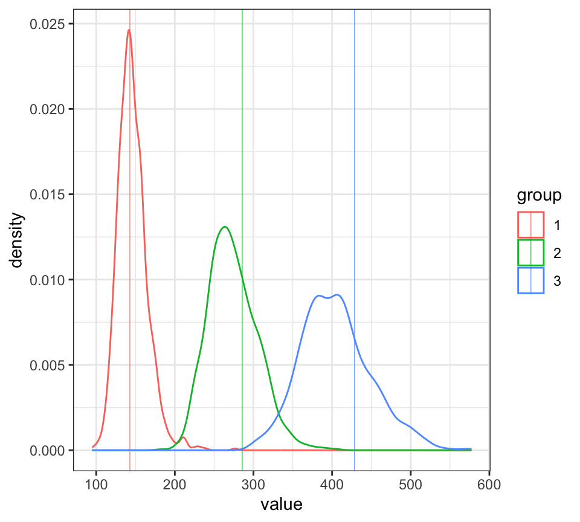

Figure 1: Posterior means per million cells by group

```r
d_post <- data.table(f1$draws(variables = c("mu"), format = "matrix"))
d_post <- melt(d_post, measure.vars = names(d_post))

d_fig_1 <- copy(d_post)
d_fig_1[, group := gsub("mu\\[", "", variable)]
d_fig_1[, group := as.factor(gsub("\\]", "", group))]

d_fig_2 <- data.table(
  group = factor(1:3),
  tru = true_rates * 1e6
)


ggplot(d_fig_1, aes(x = value, group = group, col = group)) +
  geom_vline(
    data = d_fig_2,
    aes(xintercept = tru, group = group, col = group),
    lwd = 0.2
  ) +
  geom_density() +
  theme_bw()
```

**Posterior predictive implementation**

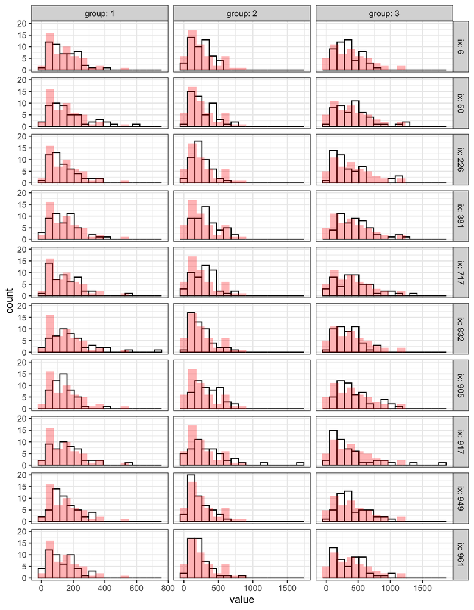

Figure 2: Posterior predictive (counts per million) based on 10 samples of equal size to what we observed (in red) by vaccine group

```r
d_post <- data.table(f1$draws(variables = c("y_rep"), format = "matrix"))
d_post[, ix := 1:.N]
d_post <- melt(d_post, id.vars = "ix")

ix_rnd <- sort(sample(1:max(d_post$ix), size = 10, replace = F))
d_fig_1 <- copy(d_post[ix %in% ix_rnd])
d_fig_1[, id := gsub("y_rep\\[", "", variable)]
d_fig_1[, id := as.integer(gsub("\\]", "", id))]
d_fig_1[, group := d_sim[id, group]]


ggplot(d_fig_1, aes(x = value)) +
  geom_histogram(
    fill = "white", col = "black", bins = 17
  ) +
  geom_histogram(
    data = d_sim,
    aes(x = 1e6 * response / cells_per_well),
    fill = "red", alpha = 0.3, bins = 15, lwd = 0.3
  ) +
  theme_bw() +
  ggh4x::facet_grid2(ix ~ group, scales = "free_x", labeller = label_both)
```